# **Problem Statement**

#### **Business Context**

Understanding customer personality and behavior is pivotal for businesses to enhance customer satisfaction and increase revenue. Segmentation based on a customer's personality, demographics, and purchasing behavior allows companies to create tailored marketing campaigns, improve customer retention, and optimize product offerings.

A leading retail company with a rapidly growing customer base seeks to gain deeper insights into their customers' profiles. The company recognizes that understanding customer personalities, lifestyles, and purchasing habits can unlock significant opportunities for personalizing marketing strategies and creating loyalty programs. These insights can help address critical business challenges, such as improving the effectiveness of marketing campaigns, identifying high-value customer groups, and fostering long-term relationships with customers.

With the competition intensifying in the retail space, moving away from generic strategies to more targeted and personalized approaches is essential for sustaining a competitive edge.

#### **Objective**

In an effort to optimize marketing efficiency and enhance customer experience, the company has embarked on a mission to identify distinct customer segments. By understanding the characteristics, preferences, and behaviors of each group, the company aims to:

1. Develop personalized marketing campaigns to increase conversion rates.
2. Create effective retention strategies for high-value customers.
3. Optimize resource allocation, such as inventory management, pricing strategies, and store layouts.

As a data scientist tasked with this project, your responsibility is to analyze the given customer data, apply machine learning techniques to segment the customer base, and provide actionable insights into the characteristics of each segment.

#### **Data Dictionary**

The dataset includes historical data on customer demographics, personality traits, and purchasing behaviors. Key attributes are:

1. **Customer Information**
   - **ID:** Unique identifier for each customer.
   - **Year_Birth:** Customer's year of birth.
   - **Education:** Education level of the customer.
   - **Marital_Status:** Marital status of the customer.
   - **Income:** Yearly household income (in dollars).
   - **Kidhome:** Number of children in the household.
   - **Teenhome:** Number of teenagers in the household.
   - **Dt_Customer:** Date when the customer enrolled with the company.
   - **Recency:** Number of days since the customer’s last purchase.
   - **Complain:** Whether the customer complained in the last 2 years (1 for yes, 0 for no).
2. **Spending Information (Last 2 Years)**
   - **MntWines:** Amount spent on wine.
   - **MntFruits:** Amount spent on fruits.
   - **MntMeatProducts:** Amount spent on meat.
   - **MntFishProducts:** Amount spent on fish.
   - **MntSweetProducts:** Amount spent on sweets.
   - **MntGoldProds:** Amount spent on gold products.
3. **Purchase and Campaign Interaction**
   - **NumDealsPurchases:** Number of purchases made using a discount.
   - **AcceptedCmp1:** Response to the 1st campaign (1 for yes, 0 for no).
   - **AcceptedCmp2:** Response to the 2nd campaign (1 for yes, 0 for no).
   - **AcceptedCmp3:** Response to the 3rd campaign (1 for yes, 0 for no).
   - **AcceptedCmp4:** Response to the 4th campaign (1 for yes, 0 for no).
   - **AcceptedCmp5:** Response to the 5th campaign (1 for yes, 0 for no).
   - **Response:** Response to the last campaign (1 for yes, 0 for no).
4. **Shopping Behavior**
   - **NumWebPurchases:** Number of purchases made through the company’s website.
   - **NumCatalogPurchases:** Number of purchases made using catalogs.
   - **NumStorePurchases:** Number of purchases made directly in stores.
   - **NumWebVisitsMonth:** Number of visits to the company’s website in the last month.

# **Let's start coding!**

## **Importing necessary libraries**

```python
# Libraries to help with reading and manipulating data
import pandas as pd
import numpy as np

# libaries to help with data visualization
import matplotlib.pyplot as plt
import seaborn as sns

# Removes the limit for the number of displayed columns
pd.set_option("display.max_columns", None)
# Sets the limit for the number of displayed rows
pd.set_option("display.max_rows", 200)

# to scale the data using z-score
from sklearn.preprocessing import StandardScaler

# to compute distances
from scipy.spatial.distance import cdist, pdist

# to perform k-means clustering and compute silhouette scores
from sklearn.cluster import KMeans
from sklearn.metrics import silhouette_score

# to visualize the elbow curve and silhouette scores
from yellowbrick.cluster import KElbowVisualizer, SilhouetteVisualizer

# to suppress warnings
import warnings

warnings.filterwarnings("ignore")
```

## **Loading the data**

```python
# uncomment and run the following line if using Google Colab
from google.colab import drive
drive.mount('/content/drive')
```

```python
# loading data into a pandas dataframe
data = pd.read_csv("/content/Customer_Personality_Segmentation.csv", sep="\t")
data.head()
```

|  | ID | Year_Birth | Education | Marital_Status | Income | Kidhome | Teenhome | Dt_Customer | Recency | MntWines | MntFruits | MntMeatProducts | MntFishProducts | MntSweetProducts | MntGoldProds | NumDealsPurchases | NumWebPurchases | NumCatalogPurchases | NumStorePurchases | NumWebVisitsMonth | AcceptedCmp3 | AcceptedCmp4 | AcceptedCmp5 | AcceptedCmp1 | AcceptedCmp2 | Complain | Z_CostContact | Z_Revenue | Response |
| --- | --- | --- | --- | --- | --- | --- | --- | --- | --- | --- | --- | --- | --- | --- | --- | --- | --- | --- | --- | --- | --- | --- | --- | --- | --- | --- | --- | --- | --- |
| 0 | 5524 | 1957 | Graduation | Single | 58138.0 | 0 | 0 | 04-09-2012 | 58 | 635 | 88 | 546 | 172 | 88 | 88 | 3 | 8 | 10 | 4 | 7 | 0 | 0 | 0 | 0 | 0 | 0 | 3 | 11 | 1 |
| 1 | 2174 | 1954 | Graduation | Single | 46344.0 | 1 | 1 | 08-03-2014 | 38 | 11 | 1 | 6 | 2 | 1 | 6 | 2 | 1 | 1 | 2 | 5 | 0 | 0 | 0 | 0 | 0 | 0 | 3 | 11 | 0 |
| 2 | 4141 | 1965 | Graduation | Together | 71613.0 | 0 | 0 | 21-08-2013 | 26 | 426 | 49 | 127 | 111 | 21 | 42 | 1 | 8 | 2 | 10 | 4 | 0 | 0 | 0 | 0 | 0 | 0 | 3 | 11 | 0 |
| 3 | 6182 | 1984 | Graduation | Together | 26646.0 | 1 | 0 | 10-02-2014 | 26 | 11 | 4 | 20 | 10 | 3 | 5 | 2 | 2 | 0 | 4 | 6 | 0 | 0 | 0 | 0 | 0 | 0 | 3 | 11 | 0 |
| 4 | 5324 | 1981 | PhD | Married | 58293.0 | 1 | 0 | 19-01-2014 | 94 | 173 | 43 | 118 | 46 | 27 | 15 | 5 | 5 | 3 | 6 | 5 | 0 | 0 | 0 | 0 | 0 | 0 | 3 | 11 | 0 |

## **Data Overview**

#### **Question 1**: What are the data types of all the columns?

```python
# Write your code here.
data.info()
```

```
<class 'pandas.core.frame.DataFrame'>
RangeIndex: 2240 entries, 0 to 2239
Data columns (total 29 columns):
 #   Column               Non-Null Count  Dtype
---  ------               --------------  -----
 0   ID                   2240 non-null   int64
 1   Year_Birth           2240 non-null   int64
 2   Education            2240 non-null   object
 3   Marital_Status       2240 non-null   object
 4   Income               2216 non-null   float64
 5   Kidhome              2240 non-null   int64
 6   Teenhome             2240 non-null   int64
 7   Dt_Customer          2240 non-null   object
 8   Recency              2240 non-null   int64
 9   MntWines             2240 non-null   int64
```

[output cut: 21 more lines]

##### **Observations:**

Education, Marital_Status → object (categorical)

Income → float (numeric, check for missing values)

Dt_Customer → object → should be converted to datetime

Spending & Purchase columns → integer (numeric, ready for scaling)

Response & AcceptedCmp → integer (categorical, can remain numeric)

```python
data['Dt_Customer'] = pd.to_datetime(data['Dt_Customer'], dayfirst=True, errors='coerce')
print(data['Dt_Customer'].dtypes)
data['Dt_Customer'].head()
```

```
datetime64[ns]
```

|  | Dt_Customer |
| --- | --- |
| 0 | 2012-09-04 |
| 1 | 2014-03-08 |
| 2 | 2013-08-21 |
| 3 | 2014-02-10 |
| 4 | 2014-01-19 |

**dtype:** datetime64[ns]

[output not shown]

#### **Question 2:** Check the statistical summary of the data. What is the average household income?

```python
# Write your code here
data.describe().T
```

|  | count | mean | min | 25% | 50% | 75% | max | std |
| --- | --- | --- | --- | --- | --- | --- | --- | --- |
| ID | 2240.0 | 5592.159821 | 0.0 | 2828.25 | 5458.5 | 8427.75 | 11191.0 | 3246.662198 |
| Year_Birth | 2240.0 | 1968.805804 | 1893.0 | 1959.0 | 1970.0 | 1977.0 | 1996.0 | 11.984069 |
| Income | 2216.0 | 52247.251354 | 1730.0 | 35303.0 | 51381.5 | 68522.0 | 666666.0 | 25173.076661 |
| Kidhome | 2240.0 | 0.444196 | 0.0 | 0.0 | 0.0 | 1.0 | 2.0 | 0.538398 |
| Teenhome | 2240.0 | 0.50625 | 0.0 | 0.0 | 0.0 | 1.0 | 2.0 | 0.544538 |
| Dt_Customer | 2240 | 2013-07-10 10:01:42.857142784 | 2012-07-30 00:00:00 | 2013-01-16 00:00:00 | 2013-07-08 12:00:00 | 2013-12-30 06:00:00 | 2014-06-29 00:00:00 | NaN |
| Recency | 2240.0 | 49.109375 | 0.0 | 24.0 | 49.0 | 74.0 | 99.0 | 28.962453 |
| MntWines | 2240.0 | 303.935714 | 0.0 | 23.75 | 173.5 | 504.25 | 1493.0 | 336.597393 |
| MntFruits | 2240.0 | 26.302232 | 0.0 | 1.0 | 8.0 | 33.0 | 199.0 | 39.773434 |
| MntMeatProducts | 2240.0 | 166.95 | 0.0 | 16.0 | 67.0 | 232.0 | 1725.0 | 225.715373 |
| MntFishProducts | 2240.0 | 37.525446 | 0.0 | 3.0 | 12.0 | 50.0 | 259.0 | 54.628979 |
| MntSweetProducts | 2240.0 | 27.062946 | 0.0 | 1.0 | 8.0 | 33.0 | 263.0 | 41.280498 |
| MntGoldProds | 2240.0 | 44.021875 | 0.0 | 9.0 | 24.0 | 56.0 | 362.0 | 52.167439 |
| NumDealsPurchases | 2240.0 | 2.325 | 0.0 | 1.0 | 2.0 | 3.0 | 15.0 | 1.932238 |
| NumWebPurchases | 2240.0 | 4.084821 | 0.0 | 2.0 | 4.0 | 6.0 | 27.0 | 2.778714 |
| NumCatalogPurchases | 2240.0 | 2.662054 | 0.0 | 0.0 | 2.0 | 4.0 | 28.0 | 2.923101 |
| NumStorePurchases | 2240.0 | 5.790179 | 0.0 | 3.0 | 5.0 | 8.0 | 13.0 | 3.250958 |
| NumWebVisitsMonth | 2240.0 | 5.316518 | 0.0 | 3.0 | 6.0 | 7.0 | 20.0 | 2.426645 |
| AcceptedCmp3 | 2240.0 | 0.072768 | 0.0 | 0.0 | 0.0 | 0.0 | 1.0 | 0.259813 |
| AcceptedCmp4 | 2240.0 | 0.074554 | 0.0 | 0.0 | 0.0 | 0.0 | 1.0 | 0.262728 |
| AcceptedCmp5 | 2240.0 | 0.072768 | 0.0 | 0.0 | 0.0 | 0.0 | 1.0 | 0.259813 |
| AcceptedCmp1 | 2240.0 | 0.064286 | 0.0 | 0.0 | 0.0 | 0.0 | 1.0 | 0.245316 |
| AcceptedCmp2 | 2240.0 | 0.013393 | 0.0 | 0.0 | 0.0 | 0.0 | 1.0 | 0.114976 |
| Complain | 2240.0 | 0.009375 | 0.0 | 0.0 | 0.0 | 0.0 | 1.0 | 0.096391 |
| Z_CostContact | 2240.0 | 3.0 | 3.0 | 3.0 | 3.0 | 3.0 | 3.0 | 0.0 |
| Z_Revenue | 2240.0 | 11.0 | 11.0 | 11.0 | 11.0 | 11.0 | 11.0 | 0.0 |
| Response | 2240.0 | 0.149107 | 0.0 | 0.0 | 0.0 | 0.0 | 1.0 | 0.356274 |

##### **Observations:**

Household Income

-Average household income is ≈ 52,247.

-Median (50%) income is slightly lower at ≈ 51,381, suggesting a fairly balanced distribution with some high-income outliers.

-Maximum income recorded is 666,666, which looks like an extreme outlier and may need capping (winsorization).

-There are 24 missing values (count = 2216 vs 2240 total).

#### **Question 3:** Are there any missing values in the data? If yes, treat them using an appropriate method

```python
# Write your code here
data.isnull().sum()
```

|  | 0 |
| --- | --- |
| ID | 0 |
| Year_Birth | 0 |
| Education | 0 |
| Marital_Status | 0 |
| Income | 24 |
| Kidhome | 0 |
| Teenhome | 0 |
| Dt_Customer | 0 |
| Recency | 0 |
| MntWines | 0 |
| MntFruits | 0 |
| MntMeatProducts | 0 |
| MntFishProducts | 0 |
| MntSweetProducts | 0 |
| MntGoldProds | 0 |
| NumDealsPurchases | 0 |
| NumWebPurchases | 0 |
| NumCatalogPurchases | 0 |
| NumStorePurchases | 0 |
| NumWebVisitsMonth | 0 |
| AcceptedCmp3 | 0 |
| AcceptedCmp4 | 0 |
| AcceptedCmp5 | 0 |
| AcceptedCmp1 | 0 |
| AcceptedCmp2 | 0 |
| Complain | 0 |
| Z_CostContact | 0 |
| Z_Revenue | 0 |
| Response | 0 |

**dtype:** int64

```python
data['Income'] = data['Income'].fillna(data['Income'].median())
```

##### **Observations:**

24 missing values imputed with median (~51,381) instead of mean, since income is skewed due to outliers.

#### **Question 4**: Are there any duplicates in the data?

```python
# Write your code here
# Count duplicate rows
duplicates = data.duplicated().sum()
print("Number of duplicate rows:", duplicates)
```

```
Number of duplicate rows: 0
```

##### **Observations:**

No duplicate rows found. Dataset is clean.

## **Exploratory Data Analysis**

### Univariate Analysis

#### **Question 5:** Explore all the variables and provide observations on their distributions. (histograms and boxplots)

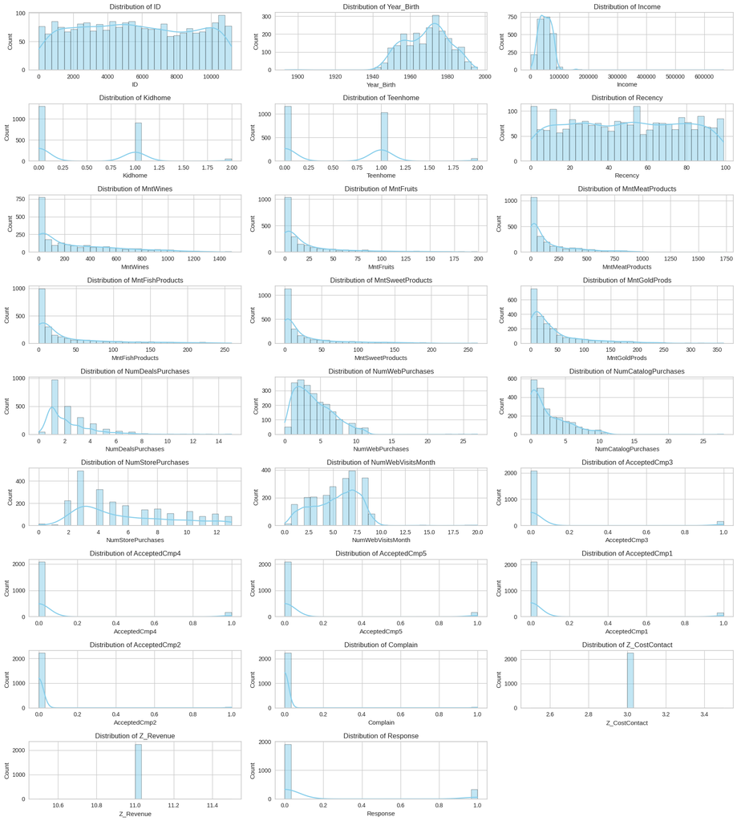

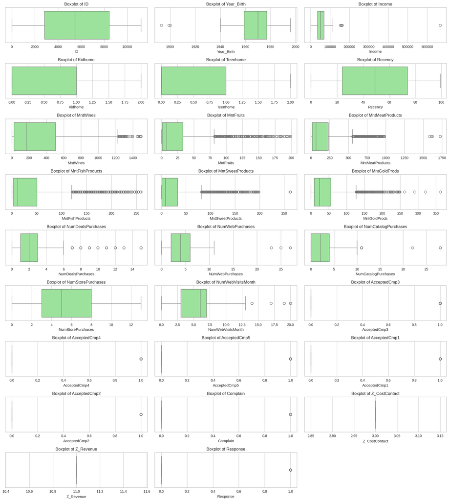

```python
# Write your code here
# Select numeric columns
num_cols = data.select_dtypes(include=['int64','float64']).columns

# Histograms
plt.figure(figsize=(18, 20))
for i, col in enumerate(num_cols, 1):
    plt.subplot(len(num_cols)//3 + 1, 3, i)
    sns.histplot(data[col], kde=True, bins=30, color='skyblue')
    plt.title(f"Distribution of {col}")
plt.tight_layout()
plt.show()

# Boxplots
plt.figure(figsize=(18, 20))
for i, col in enumerate(num_cols, 1):
    plt.subplot(len(num_cols)//3 + 1, 3, i)
    sns.boxplot(x=data[col], color='lightgreen')
    plt.title(f"Boxplot of {col}")
plt.tight_layout()
plt.show()
```

### Bivariate Analysis

#### **Question 6:** Perform multivariate analysis to explore the relationsips between the variables.

[figure not shown]

```python
# Compute correlation only for numeric columns
plt.figure(figsize=(15,10))
corr = data.select_dtypes(include=['int64','float64']).corr()

sns.heatmap(corr, annot=False, cmap="coolwarm", linewidths=0.5)
plt.title("Correlation Heatmap of Numeric Variables", fontsize=14)
plt.show()
```

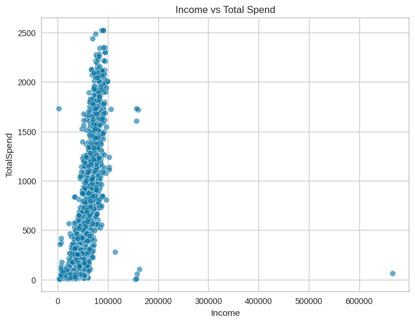

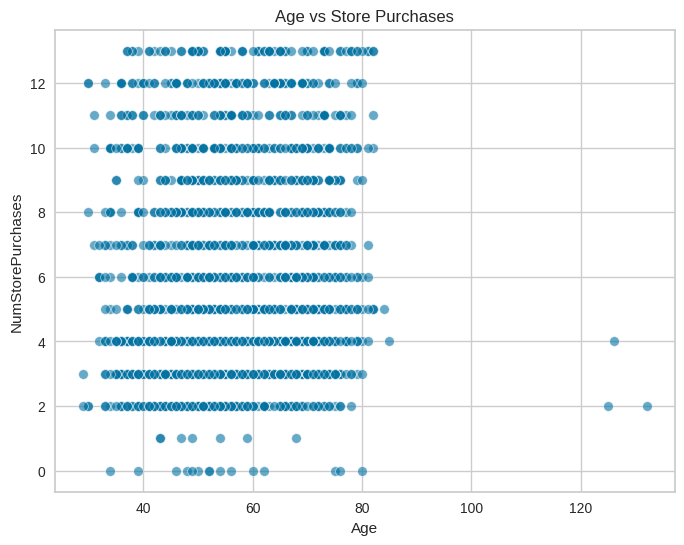

```python
# Income vs Total Spend
data['TotalSpend'] = data[['MntWines','MntFruits','MntMeatProducts',
                           'MntFishProducts','MntSweetProducts','MntGoldProds']].sum(axis=1)

plt.figure(figsize=(8,6))
sns.scatterplot(x='Income', y='TotalSpend', data=data, alpha=0.6)
plt.title("Income vs Total Spend")
plt.show()

# Age vs Total Purchases
data['Age'] = 2025 - data['Year_Birth']

plt.figure(figsize=(8,6))
sns.scatterplot(x='Age', y='NumStorePurchases', data=data, alpha=0.6)
plt.title("Age vs Store Purchases")
plt.show()
```

##### **Observations:**

Spending categories (Wine, Meat, Gold, etc.) are strongly correlated → customers who spend in one category tend to spend across others.

Income positively influences spending, but not always — some high-income customers spend very little, while some middle-income customers are heavy spenders.

## **K-means Clustering**

#### **Question 7** : Select the appropriate number of clusters using the elbow Plot. What do you think is the appropriate number of clusters?